# Real Data Experiments

### Fit models and make predictions

Once the optimal hyperparameter are determined the different models are fit and are evaluated based on their performance on the test data. LDA and QDA are excludud from the analysis of this dataset as the computation of their covariance matrix does not hold for that amount of dummy valriables.

```r
classifiers <- c(
  "adaboost",  "bagging", "knn",
  "logit", "logit_nnet",
  "mlpc", "nb_bernulli", "nb_gaussian",
  "probability_forest", "ranger", "svm", "xgboost"
)
classifiers_mc <- c(
  "knn", "lda", "logit", "logit_nnet",
  "mlpc", "nb_bernulli", "nb_gaussian",
  "probability_forest", "ranger", "qda"
)

tuning_results <- readRDS(paste0("sim_results/tuning_results_", dataname, ".rds"))
tuned_classifiers <- names(tuning_results)

n = nrow(X_training)
t = length(unique(W_training))

results <- list()


for (c in seq_along(classifiers)) {
  classifier <- classifiers[c]
  print(classifier)

  # Multi-class model
  if (classifier %in% classifiers_mc){
    if (classifier %in% tuned_classifiers){
      params_raw <- tuning_results[[classifier]]$best_params
      params_raw$BS <- NULL
      rownames(params_raw) <- NULL
      params <- list()
      # Store tuning parameters
      for (col_name in colnames(params_raw)) {
        if (is.factor(params_raw[[col_name]])) {
          params[[col_name]] <- as.character(params_raw[[col_name]][1])
        } else {
          params[[col_name]] <- params_raw[[col_name]][1]
        }
      }
    }else{
      params = list()
    }


    # fit model
    model <- do.call(paste0(classifier, "_fit"), list(x = X_training, y = W_training, params))

    # predict
    predictions <- do.call(paste0("predict.", classifier, "_fit"),
                                       list(model, X_training, W_training, xnew = X_test))

    results[[classifier]] <- as.data.frame(predictions) # Store the results
  }

  # fit OvR model
  model <- do.call(ovr_fit,
                   list(x = X_training, y = W_training,
                   method = classifier))
  # predict
  predictions <- do.call(predict.ovr_fit,
                   list(model, x = X_training, y = W_training, xnew = X_test,
                        method = classifier))

  predictions <- predictions[, order(names(predictions))]
  results[[paste0("ovr_", classifier)]] <- predictions # Store the results


  # fit OvO model
  model <- do.call(ovo_fit,
                   list(x = X_training, y = W_training,
                   method = classifier))
  # predict
  predictions <- do.call(predict.ovo_fit,
                   list(model, x = X_training, y = W_training, xnew = X_test,
                        method = classifier))
  #predictions <- predictions[, order(names(predictions))]
  results[[paste0("ovo_", classifier)]] <- as.data.frame(predictions) # Store the results

}

saveRDS(results, file = paste0("sim_results/results_", dataname, ".rds"))
```

### Evaluation of results

The results are reshaped such that there is one row for each classification model and one column for ech implementation strategy. Lastly, the results are exported.

```r
results <- readRDS(file = paste0("sim_results/results_", dataname, ".rds"))

bs_mat <- matrix(nrow = length(names(results)), ncol = 2)
colnames(bs_mat) <- c("name", "value")

for (i in seq_along(names(results))) {
  bs_mat[i, "name"] <- names(results)[i]
  bs_mat[i, "value"] <- brier_score(probabilities = results[[i]], outcome = W_test)
}

bs_long <- bs_mat %>%
  as.data.frame() %>%
  # Separate the 'name' into 'classifier' and 'version' columns
  mutate(version = case_when(
           str_detect(name, "^ovr_") ~ "one-vs-rest",
           str_detect(name, "^ovo_") ~ "one-vs-one",
           TRUE ~ "multi-class"
         ),
         name = gsub("ovr_|ovo_", "", name),
         value = as.numeric(value)
         )

bs_wide <- bs_long %>%
  group_by(version, name) %>%
  summarise(value = round(mean(value), 4)) %>%
  spread(key = version, value = value)
#
write.xlsx(bs_wide, file = paste0("sim_results/results_bs_", dataname, ".xlsx"))

kable(bs_wide, caption = "Brier Score")
```

Brier Score

| name | multi-class | one-vs-one | one-vs-rest |
| --- | --- | --- | --- |
| adaboost | NA | 0.1232 | 0.1245 |
| bagging | NA | 0.1183 | 0.1168 |
| knn | 0.1527 | 0.1525 | 0.1560 |
| logit | 0.1157 | 0.4881 | 0.1161 |
| logit_nnet | 0.1128 | 0.1156 | 0.1165 |
| mlpc | 0.1455 | 0.1247 | 0.1491 |
| nb_bernulli | 0.5016 | 0.4949 | 0.2121 |
| nb_gaussian | 0.5016 | 0.4949 | 0.2121 |
| probability_forest | 0.1174 | 0.1183 | 0.1177 |
| ranger | 0.1137 | 0.1234 | 0.1240 |
| svm | NA | 0.1939 | 0.1541 |
| xgboost | NA | 0.2798 | 0.1760 |

```r
NA
```

### Calibration plots

The calibration plot is a visualization tool used to assess the performance of probabilistic classification models. This helps to evaluate how well these predicted probabilities align with the actual likelihood of the events being predicted.

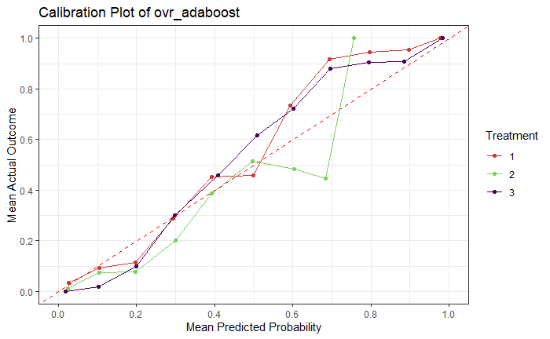

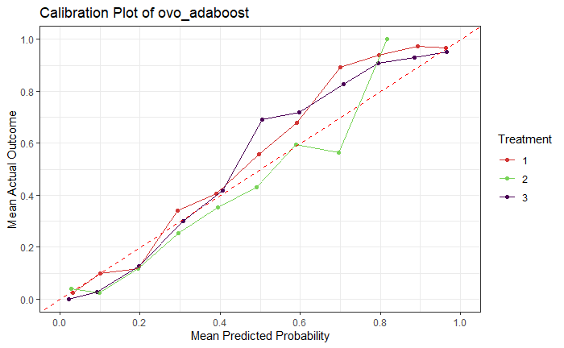

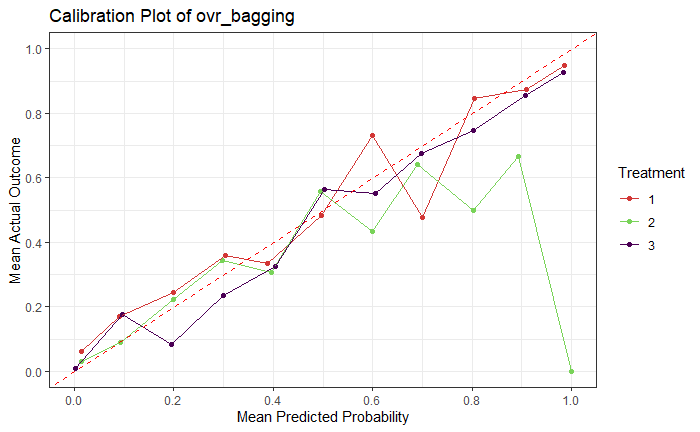

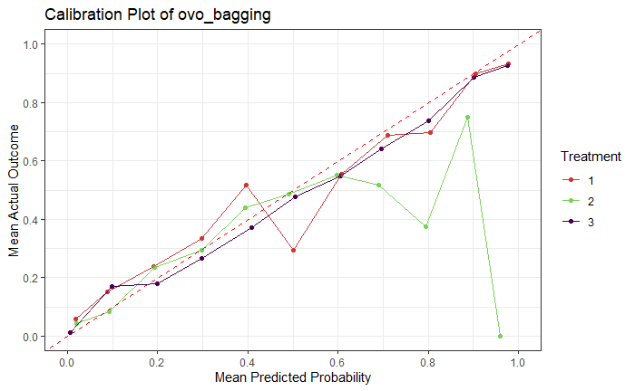

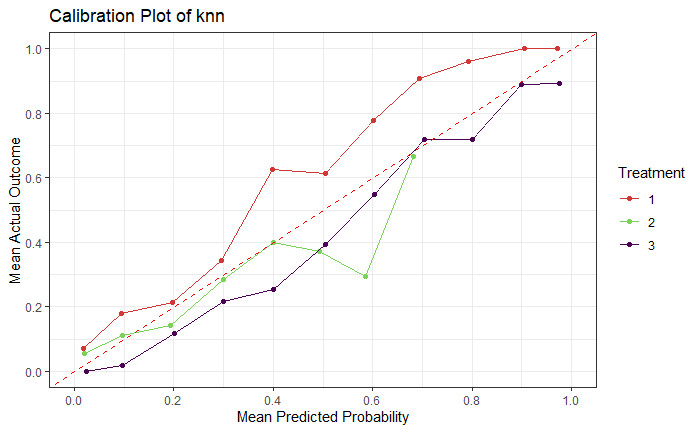

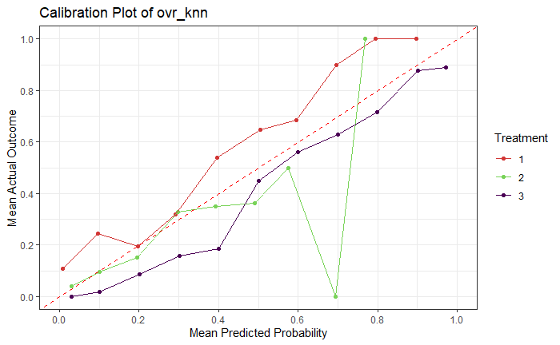

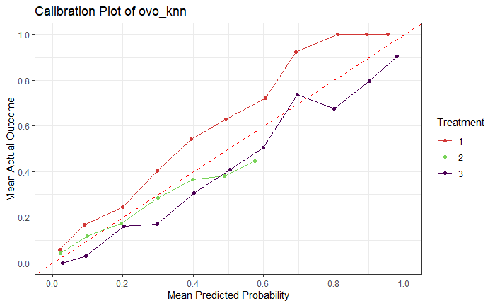

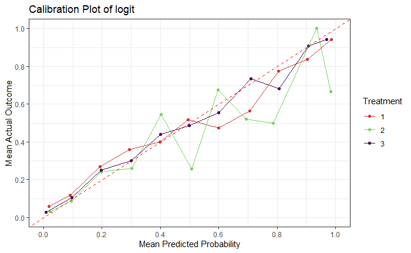

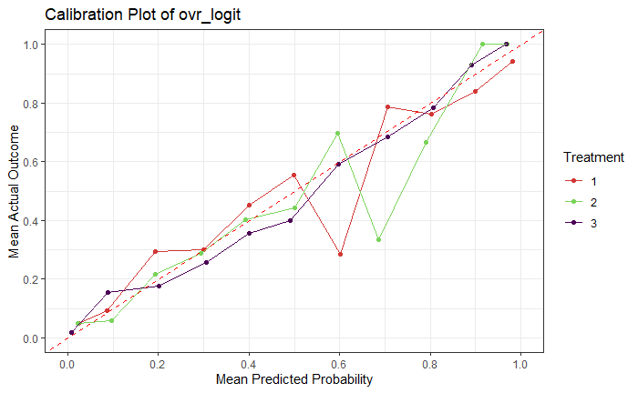

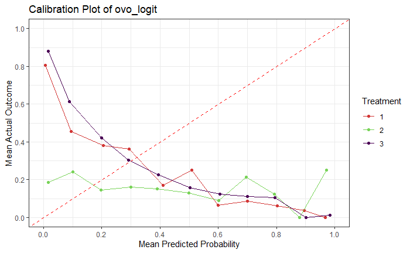

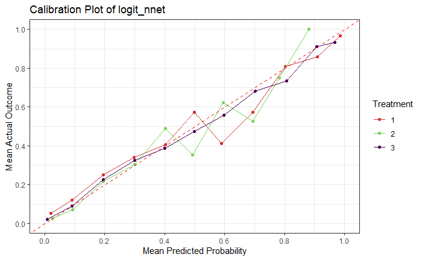

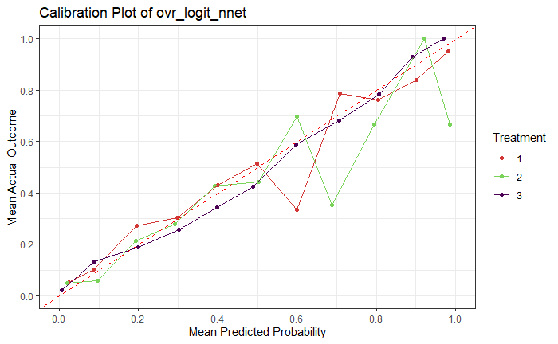

[20 more figures not shown]

```r
for (c in names(results)){
  p <- make_calibtation_plot(probabilities = results[[c]], outcome = W_test, method = c)
  plot(p)
  ggsave(p, file = paste0("plots/",c, "_student.png"),
         width = 120, height = 100, units = "mm")
}
```